# PISA 2012 Visual Data Exploration

## Preliminary Wrangling

The PISA study dataset record features about students across the world from different educational systems. More specifically, it looks at their level of preparation and results at school. It also provides features about the students background and attitude toward learning.

```python
import numpy as np
import pandas as pd
import matplotlib.pyplot as plt
import seaborn as sb

%matplotlib inline
```

The dataset provides numerous features and cannot be manipulated as of now. Below is some exploration and selection of the features we are interested in.

The below markdown cell can be turned into code and used to create a CSV file with the dataset trimmed with the selected features. This will permit to use load directly the shortlisted dataset in the explanatory data visualisation file.

### What is the structure of your dataset?

The PISA study information is a structured dataset which follow the principles of tidiness of data. There are 485490 observations recorded with about 630 features (shortlisted to 20). Most variables are categorical but some are numerical.

### What is/are the main feature(s) of interest in your dataset?

The dataset is made of 630 different features about the student characteristics and prepration durung their education. You can find general information about the students and their origins, information about their education and social background. Finally, the dataset is also providing features about how the students are doing at school and their performances.

Documentation about the plausible values (gauging performance): https://www.oecd-ilibrary.org/docserver/9789264056275-7-en.pdf?expires=1569153995&id=id&accname=guest&checksum=97184E3B4AE5AAC27E429626E5C512F7

### What features in the dataset do you think will help support your investigation into your feature(s) of interest?

I shortlisted those to the main characteristics of the students (country, student id, gender..), their social background (parent's education level, time spent with parents at home, language spoken at home, IT equipment at home...), their working ethic (perseverance, study time...) and their performance at shcool (maths, reading and science). I expect that higher parent's education will result in a better performance at school.

## Univariate Exploration

Let's take a closer look at the distributions of our variables. Data wrangling has been performed above, below is the code to reload the data:

```python
df_sub = pd.read_csv('pisa_sub.csv')
df_sub.head()
```

|  | country | OECD | student_id | gender | truancy | lang_home | time_homework | time_parents | time_computer | home_desktop | home_laptop | home_tablet | math_concepts | edu_lvl_parents | math_interest | perseverance | learning_time_sci | perf_math | perf_read | perf_sci |
| --- | --- | --- | --- | --- | --- | --- | --- | --- | --- | --- | --- | --- | --- | --- | --- | --- | --- | --- | --- | --- |
| 0 | Albania | Non-OECD | 1 | Female | None | Language of the test | NaN | NaN | NaN | NaN | NaN | NaN | NaN | ISCED 3A, ISCED 4 | 0.91 | -0.3407 | NaN | 406.8469 | 249.5762 | 341.7009 |
| 1 | Albania | Non-OECD | 2 | Female | None | Language of the test | NaN | 0.0 | 2.0 | NaN | NaN | NaN | 0.6387 | ISCED 5A, 6 | 0.00 | 1.3116 | 90.0 | 486.1427 | 406.2936 | 548.9929 |
| 2 | Albania | Non-OECD | 3 | Female | None | Language of the test | NaN | 2.0 | 3.0 | NaN | NaN | NaN | 0.8215 | ISCED 5A, 6 | 1.23 | 0.9918 | NaN | 533.2684 | 401.2100 | 499.6643 |
| 3 | Albania | Non-OECD | 4 | Female | None | Language of the test | 10.0 | 0.0 | 3.0 | NaN | NaN | NaN | 0.7266 | ISCED 5A, 6 | NaN | NaN | 90.0 | 412.2215 | 547.3630 | 438.6796 |
| 4 | Albania | Non-OECD | 5 | Female | None | Language of the test | NaN | NaN | NaN | NaN | NaN | NaN | NaN | ISCED 3A, ISCED 4 | 0.30 | 1.0819 | NaN | 381.9209 | 311.7707 | 361.5628 |

### Students features

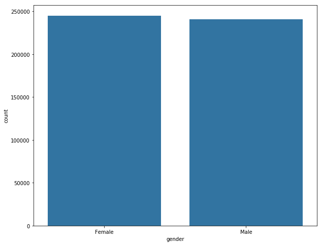

```python
plt.subplots(figsize = [10,8], sharex=True, sharey=True)

default_color = sb.color_palette()[0]
sb.countplot(data = df_sub, x = 'gender', color = default_color)
plt.show()
```

Female and male students are evenly represented in the dataset.

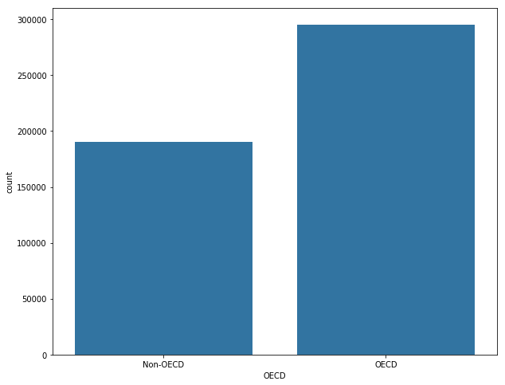

```python
plt.subplots(figsize = [10,8], sharex=True, sharey=True)

default_color = sb.color_palette()[0]
sb.countplot(data = df_sub, x = 'OECD', color = default_color)
plt.show()
```

Most of the students are living in countries members of the OECD.

Does this have consequences on their performances at school?

### Work ethic

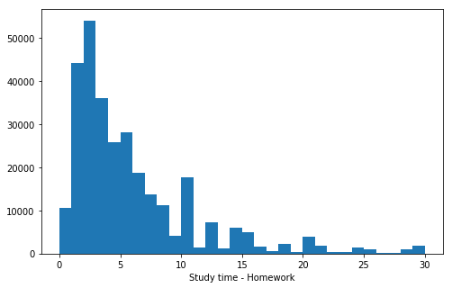

```python
binsize = 1
bins = np.arange(0, df_sub.time_homework.max()+binsize, binsize)

plt.figure(figsize=[8, 5])
plt.hist(data=df_sub, x='time_homework', bins=bins)
plt.xlabel('Study time - Homework')
plt.show()
```

Next we should observe if the study time is correlated with good results.

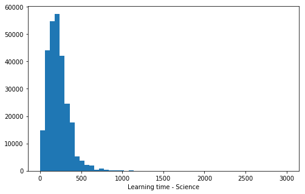

```python
binsize = 60
bins = np.arange(0, df_sub.learning_time_sci.max()+binsize, binsize)

plt.figure(figsize=[8, 5])
plt.hist(data=df_sub, x='learning_time_sci', bins=bins)
plt.xlabel('Learning time - Science')
plt.show()
```

The distribution has a long right tail, let's apply a logarithmic transformation of the scale:

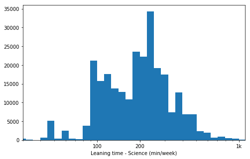

```python
log_binsize = 0.05
bins = 10 ** np.arange(0, np.log10(df_sub.learning_time_sci.max())+log_binsize, log_binsize)

plt.figure(figsize=[8, 5])
plt.hist(data=df_sub, x='learning_time_sci', bins=bins)
plt.xscale('log')
plt.xlim([30, 1100])
plt.xticks([1e2, 200,  1e3], ['100', '200', '1k'])
plt.xlabel('Leaning time - Science (min/week)')
plt.show()
```

The learning time dedicated to science has a long right tail. After arranging the scale, the distribution is roughly bimodal with peaks around 100 and 250.

An interesting point to investigate would be: is this learning time correlated with any feature of the student social background, like the diploma of the parents?

### Performance at school

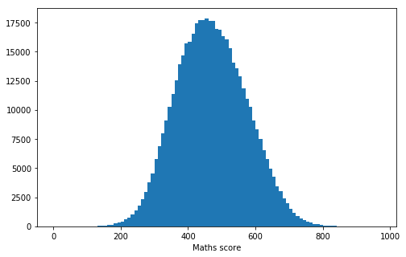

```python
binsize = 10
bins = np.arange(0, df_sub.perf_math.max()+binsize, binsize)

plt.figure(figsize=[8, 5])
plt.hist(data=df_sub, x='perf_math', bins=bins)
plt.xlabel('Maths score')
plt.show()
```

The maths performance is following a normal distribution due to its construction method: https://www.oecd-ilibrary.org/docserver/9789264056275-7-en.pdf?expires=1569153995&id=id&accname=guest&checksum=97184E3B4AE5AAC27E429626E5C512F7

We can't really draw any conclusion from the univariable analysis except that the mean value is around 450. We will add more variables like the study time or the level of education of the parents to find more insights.

### Background

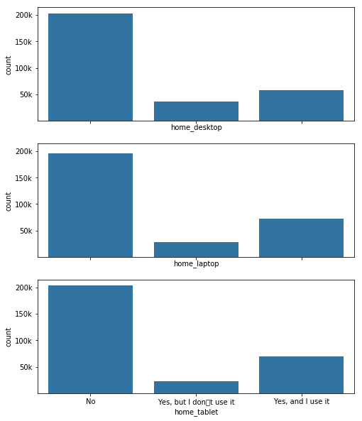

```python
fig, ax = plt.subplots(nrows=3, figsize = [8,10], sharex=True, sharey=True)

default_color = sb.color_palette()[0]
sb.countplot(data = df_sub, x = 'home_desktop', color = default_color, ax = ax[0])
sb.countplot(data = df_sub, x = 'home_laptop', color = default_color, ax = ax[1])
sb.countplot(data = df_sub, x = 'home_tablet', color = default_color, ax = ax[2])

plt.yticks([50000, 100000, 150000, 200000], ['50k', '100k', '150k', '200k'])

plt.show()
```

The majority of students in the dataset are not equiped with hardware at home. The counts are similar between one type of device to the others, the ownership of one type of device is probably associated with owning another type.

Next we should figure out if owning a computer or a laptop is associated with better results. Or alternatively, does it lead to hihger truancy and lower time dedicated to study?

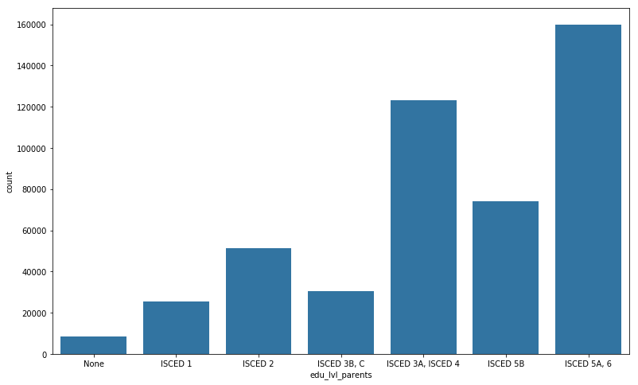

```python
plt.subplots(figsize = [13,8], sharex=True, sharey=True)

default_color = sb.color_palette()[0]
sb.countplot(data = df_sub, x = 'edu_lvl_parents', color = default_color, order=['None', 'ISCED 1', 'ISCED 2',
                                                                                'ISCED 3B, C', 'ISCED 3A, ISCED 4',
                                                                                 'ISCED 5B', 'ISCED 5A, 6'])
plt.show()
```

We observed a roughly progressive number of observations alongside the education level of the parents with highest count being 160k for 'ISCED 5A, 6' (equivalent to Doctorat). Interestingly there is a decrease in this progressive pattern for 'ISCED 3B, C' and 'ISCED 5B'.

The below page provides more details about the PISA education levels equivalents: https://en.wikipedia.org/wiki/International_Standard_Classification_of_Education#ISCED_2011_levels,_categories,_and_sub-categories

Thos feature should be compared with the results at school of the student to figure out if having parents with a high level of education helps to get better performance at school.

### Discuss the distribution(s) of your variable(s) of interest. Were there any unusual points? Did you need to perform any transformations?

The performances at school are normaly distributed and no conclusion can be drawn before moving on to a bivariate exploration. The mean maths score is around 450.

### Of the features you investigated, were there any unusual distributions? Did you perform any operations on the data to tidy, adjust, or change the form of the data? If so, why did you do this?

The learning time dedicated to science is highly concentrated between 0 and 500 minutes a week, but has a long right tail. To better represent the variable we performed a logaritmic transformation of the x scale.

## Bivariate Exploration

Let's move on with a bivariate exploration to further investigate the dataset

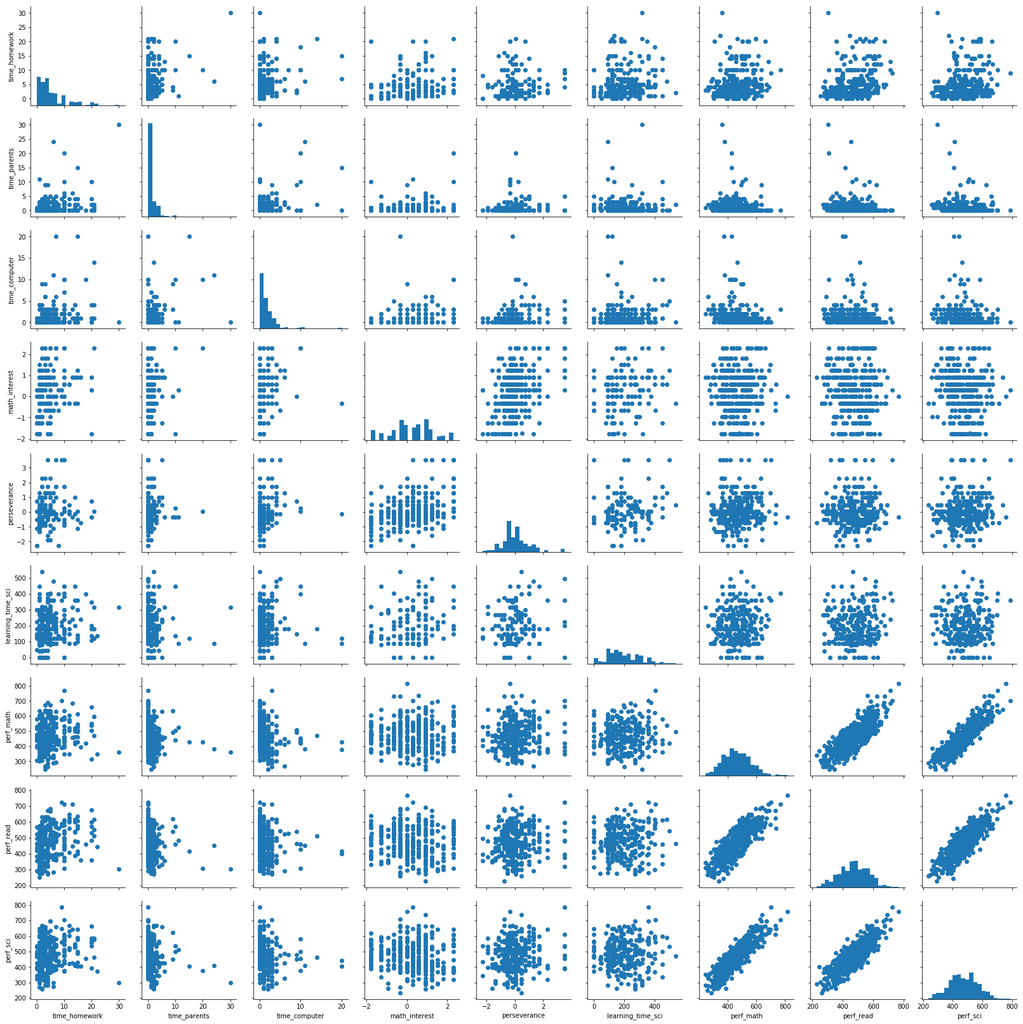

```python
samples = np.random.choice(df_sub.shape[0], 500, replace = False)
students_samp = df_sub.loc[samples,:]
numeric_vars = ['time_homework', 'time_parents', 'time_computer',
                'math_interest', 'perseverance', 'learning_time_sci',
               'perf_math','perf_read','perf_sci']

g = sb.PairGrid(data = students_samp, vars= numeric_vars)
g = g.map_diag(plt.hist, bins = 20)
g.map_offdiag(plt.scatter)
plt.show()
```

There are very few linear correlation that can be observed from a quick visual assessment. Only the performances in maths, reading and science have a strong linear relationships. Therefore, when a student is doing well in one category he is also performing well in the two others.

The discrete nature of most of the variables doesn't offer a good case for using a scatter plot analysis, we will rather use alternative plots.

### Students and performance

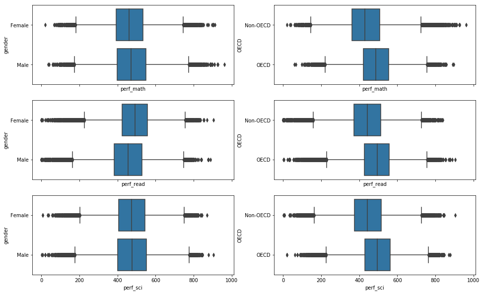

```python
fig, ax = plt.subplots(nrows= 3, ncols=2, figsize = [16,10], sharex=True)


base_color = sb.color_palette()[0]
sb.boxplot(data = df_sub, x = 'perf_math', y = 'gender', color = base_color, ax = ax[0, 0])
sb.boxplot(data = df_sub, x = 'perf_read', y = 'gender', color = base_color, ax = ax[1, 0])
sb.boxplot(data = df_sub, x = 'perf_sci', y = 'gender', color = base_color, ax = ax[2, 0])

sb.boxplot(data = df_sub, x = 'perf_math', y = 'OECD', color = base_color, ax = ax[0, 1])
sb.boxplot(data = df_sub, x = 'perf_read', y = 'OECD', color = base_color, ax = ax[1, 1])
sb.boxplot(data = df_sub, x = 'perf_sci', y = 'OECD', color = base_color, ax = ax[2, 1])

plt.show()
```

The above plots are comparing the 3 different types of performance (maths, reading and science) with two core feature of the students in the dataset separetely: gender and OECD-origin.

The first observation is that the gender doesn't really affect the results at school except for the reading performance where gitls are on average better than boys. Regarding the categorical variable 'OECD', it is clear and consistent that on average the students from OECD countries have better performances than the non-OECD ones.

Does the gender or being member of the OECD coupled with another feature like the social background have a correlation with the academic performances?

### Background and performance

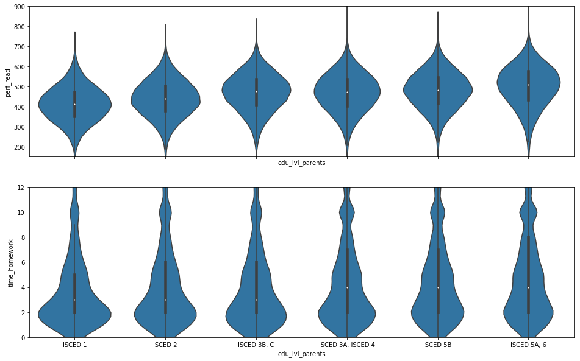

```python
fig, ax = plt.subplots(nrows= 2,figsize = [16,10], sharex=True)

default_color = sb.color_palette()[0]
sb.violinplot(data = df_sub, x = 'edu_lvl_parents', y = 'perf_read', order=['ISCED 1', 'ISCED 2',
                                                                                'ISCED 3B, C', 'ISCED 3A, ISCED 4',
                                                                                 'ISCED 5B', 'ISCED 5A, 6'],
                                                                    color=default_color,
                                                                    ax = ax[0])
ax[0].set_ylim([150, 900])


sb.violinplot(data = df_sub, x = 'edu_lvl_parents', y = 'time_homework', order=['ISCED 1', 'ISCED 2',
                                                                                'ISCED 3B, C', 'ISCED 3A, ISCED 4',
                                                                                 'ISCED 5B', 'ISCED 5A, 6'],
                                                                         color=default_color,
                                                                         ax = ax[1])
ax[1].set_ylim([0, 12])
plt.show()
```

Moreover, there is a threshold in the parents' level of education, above the 'ISCED 3A, ISCED 4' the average time spent on homeworks increase to 4 hours a week. The shape of the distribution gets finner with the increase in the level of diploma suggesting more time spent on homeworks.

How do those three variables affect each others. Are necessarily a good social background and a high number of hours spent on homeworks a paved way to higher performances?

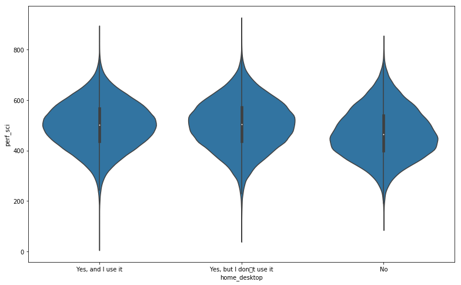

```python
plt.figure(figsize = [13,8])

default_color = sb.color_palette()[0]
sb.violinplot(data = df_sub, x = 'home_desktop', y = 'perf_sci', color=default_color)
#plt.ylim([150, 900])
plt.show()
```

### Work ethic and performance

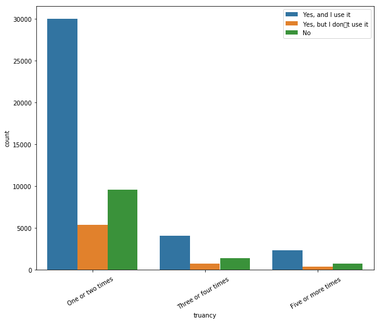

```python
df_sub_truant = df_sub.query('truancy != "None"').copy()
plt.figure(figsize=[10,8])
ax = sb.countplot(data=df_sub_truant, hue='home_desktop', x='truancy', order=['One or two times  ',
                                                                              'Three or four times  ',
                                                                              'Five or more times  '])
ax.legend()
plt.xticks(rotation=30);
```

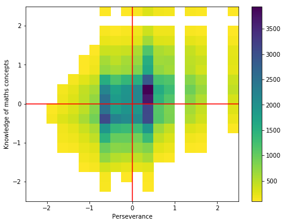

```python
plt.figure(figsize = [8, 6])
bins_x = np.arange(-4.5, 4.5+0.25, 0.25)
bins_y = np.arange(-4.5, 4.5+0.25, 0.25)
plt.hist2d(data = df_sub, x = 'perseverance', y = 'math_concepts', bins = [bins_x, bins_y],
          cmap = 'viridis_r', cmin = 100)

plt.xlabel('Perseverance')
plt.ylabel('Knowledge of maths concepts')
plt.xlim([-2.5, 2.5])
plt.ylim([-2.5, 2.5])
plt.axvline(0, color='r')
plt.axhline(0, color='r')
plt.colorbar()
plt.show()
```

Those two elements seem to be key to have good results in maths, is this always the case? Are they correlated with another feature like owning a laptop at home?

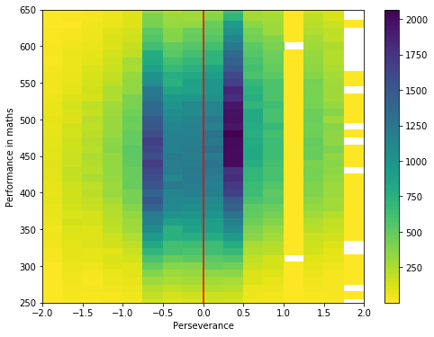

```python
plt.figure(figsize = [8, 6])
bins_x = np.arange(-4.5, 4.5+0.25, 0.25)
bins_y = np.arange(-4.5, df_sub.perf_math.max() + 10, 10)
plt.hist2d(data = df_sub, x = 'perseverance', y = 'perf_math', bins = [bins_x, bins_y],
          cmap = 'viridis_r', cmin = 0.5)

plt.xlabel('Perseverance')
plt.ylabel('Performance in maths')
plt.xlim([-2, 2])
plt.ylim([250, 650])
plt.axvline(0, color='r')
plt.colorbar()
plt.show()
```

A concentration of persevering people (0.25 to 0.5) is above the mean maths score (about 450). This suggests that a work ethic dedicated to study leads to grades above the average. Although, there is no strong correlation between the two features. Probably this is not enough to explain the performances in maths.

The sole perseverance is not enough to explain good performances in mathematics. We should explore more relationships with different features. Is perseverance coupled with the social background a key to good performance in maths?

### Talk about some of the relationships you observed in this part of the investigation. How did the feature(s) of interest vary with other features in the dataset?

From the students core characteristics, living in a country member of the OECD has been proven the main factor granting better results on average. The social background has a clear influence over the results of the student with Doctorate-gradutated parents having children with better results at school. From the work ethic point of view, perseverance is proven a factor of good knowledge of mathematical concepts but not necessarily a guarantee to get good maths results at school.

## Multivariate Exploration

The multivariate analysis will be oriented on understanding how the student characteristics, background and work ethic play together to define the performance at school.

We apply some feature engineering here to categorize persevering students:

```python
df_sub['is_persevering'] = df_sub['perseverance'].apply(lambda x: 1 if x >= 0 else 0)
```

Check:

```python
df_sub[['perseverance', 'is_persevering']].sample(5)
```

|  | perseverance | is_persevering |
| --- | --- | --- |
| 165969 | 0.0511 | 1 |
| 433715 | 0.2586 | 1 |
| 369940 | NaN | 0 |
| 34201 | 0.4795 | 1 |
| 244072 | -1.1279 | 0 |

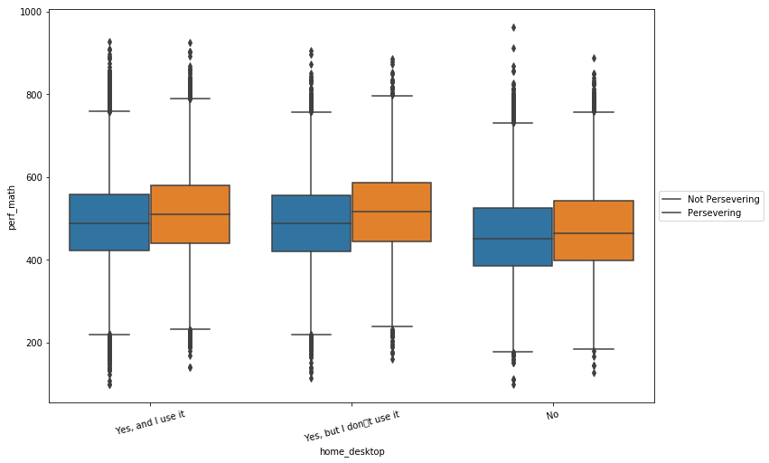

```python
plt.figure(figsize=[12,8])
sb.boxplot(data = df_sub, x = 'home_desktop', y = 'perf_math', hue = 'is_persevering')
plt.legend(labels=['Not Persevering', 'Persevering'], loc = 6, bbox_to_anchor = (1.0, 0.5))
plt.xticks(rotation = 15)
plt.show()
```

The persevering student always get better results in maths on average. Also, student owning a desktop whether they use it or not have better results in maths than students not owning a desktop at home.

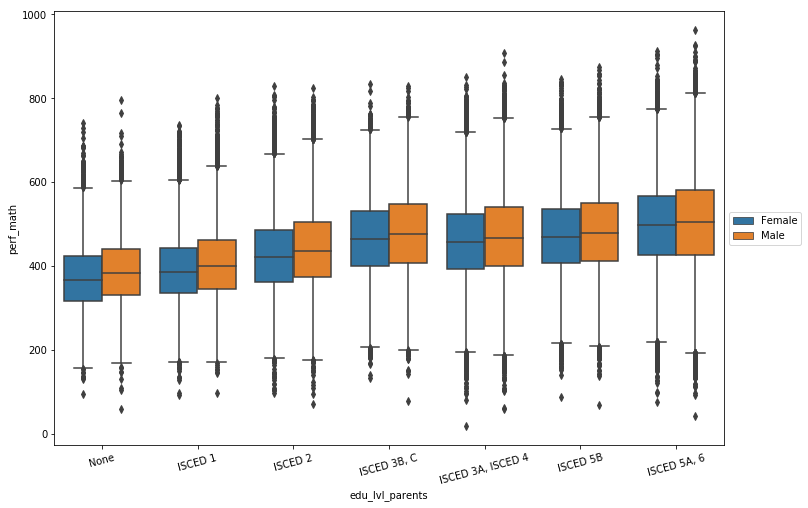

```python
plt.figure(figsize=[12,8])
sb.boxplot(data = df_sub, x = 'edu_lvl_parents', y = 'perf_math', hue = 'gender', order=['None', 'ISCED 1', 'ISCED 2',
                                                                                       'ISCED 3B, C', 'ISCED 3A, ISCED 4',
                                                                                       'ISCED 5B', 'ISCED 5A, 6'])
plt.legend(loc = 6, bbox_to_anchor = (1.0, 0.5))
plt.xticks(rotation = 15)
plt.show()
```

For the same category of perents' level of education, male students always have on trend better resutls in mathematics. Across category of parent's level of education, the children with parents holding a higher degree tends to get better results in mathematics. As a result, a male student with parents holding a bachelor degree's at most will have on trend lower maths results than a female student whose parents graduated from a Doctorate.

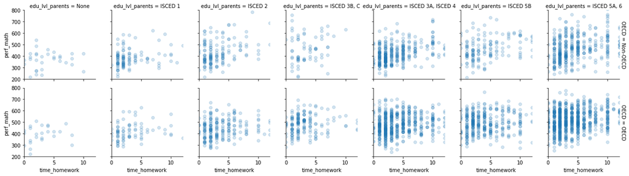

```python
samples = np.random.choice(df_sub.shape[0], 6000, replace = False)
students_samp = df_sub.loc[samples,:]

plt.figure(figsize=[16,10])
g = sb.FacetGrid(data = students_samp, col = 'edu_lvl_parents', row = 'OECD', size = 2.5,
                margin_titles = True, col_order=['None', 'ISCED 1', 'ISCED 2', 'ISCED 3B, C', 'ISCED 3A, ISCED 4',
                                                                                       'ISCED 5B', 'ISCED 5A, 6'])
g.map(plt.scatter, 'time_homework', 'perf_math', alpha = 1/5)
plt.xlim([0, 12])
plt.ylim([200, 800])
plt.show()
```

A stronger pattern appears on the OECD row, especially in the columns correcponding to a high level of education of the parents. This suggests that the time spent doing homeworks is on average more converted into good results in mathematics in the OECD country and with parents having a higher level of education.

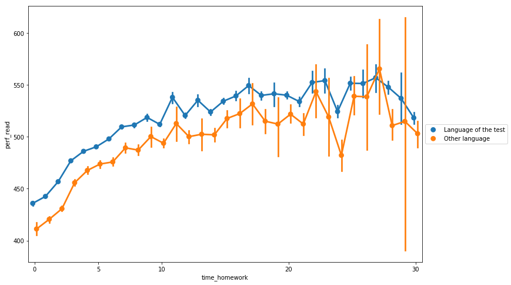

```python
plt.figure(figsize=[12,8])
ax = sb.pointplot(data = df_sub, x = 'time_homework', y = 'perf_read', hue = 'lang_home',
                  dodge = 0.3)
plt.legend(loc = 6, bbox_to_anchor = (1.0, 0.5))
plt.xticks([0, 5, 10, 20, 30],['0', '5', '10', '20', '30']);
```

Overall, the more time the students dedicate to homeworks the better are their results in reading. Interestingly, this upward trend is reversed above 28 hours a week spent on homeworks.

Moreover, students who speak a different language at home have consistently lower results in reading at school.

### Talk about some of the relationships you observed in this part of the investigation. Were there features that strengthened each other in terms of looking at your feature(s) of interest?

The work ethic coupled with a priviledge social background are two strong drivers of good performance at school. Indeed, persevering students are always rewarded with better results on average than their peers in the same social category. Although, the social background plays a role as a persevering student with a more modest background can have lower grades than his non-persevering peer with a better social background. Moreover, having parents with a high level of education helps to make the study time afficcient since the correlation between study time and results is stonger for their children.

Owning tech devices is proven helpful for persevering students but not nicessarily a factor of success overall.

The origin of the students also play a key role in their performance at school. The correlation between study time and results is stronger for students from a country member of the OECD. Moreover, students speaking a different language at home have consistently lower reading performances on average than their peers speaking the same language at home and at school.

### Were there any interesting or surprising interactions between features?

Above 28 hours spent on working on homeworks, the average performance of students is decreasing. An interesting further investigation would be to look at those students specifically and figure out if this overload is counter-productive or if it is generated by more difficulties at school.